# Dashboard Generation Profiling Notebook

## Chart (b): End-to-end throughput

Baseline-config total run wall seconds per path, stacked as generation (all batches), conversion/JSON export (legacy paths only; import-side `jsonl.gz` conversion), and the remaining DB import time. Secondary axis is **end-to-end** features/min (`features x batches x 60 / (generation_total + import_wall)`), the headline reviewer throughput metric.

Shown at the per-scenario showcase configs (Monology 4096x256, RTE 2048x128); falls back to the baseline config for older packages.

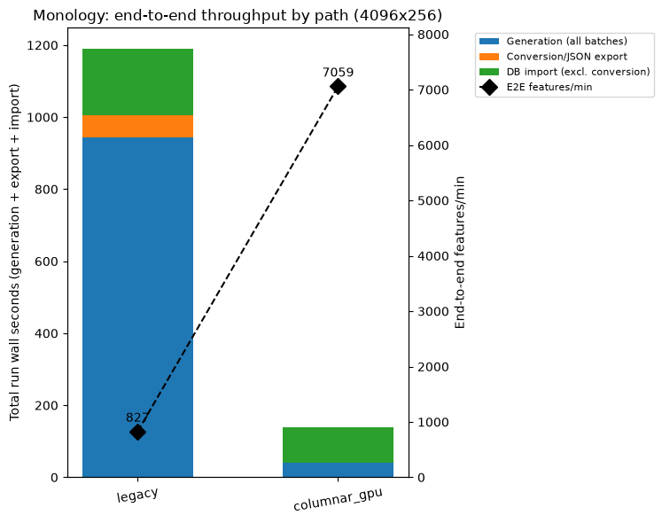

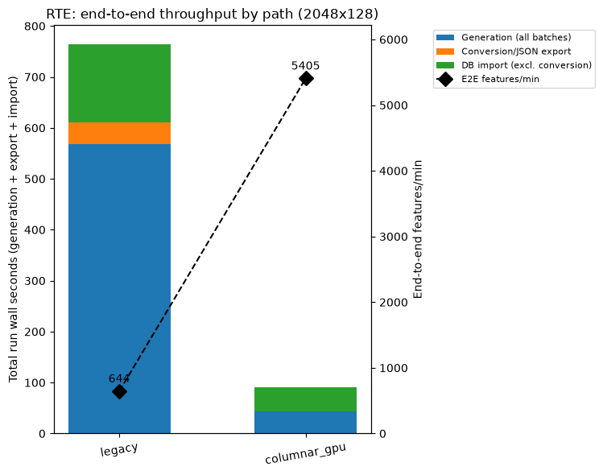

## Chart (c): 2-way scaling view grouped by path

Bars are grouped by path (in-tree legacy, then columnar_gpu) with one bar per batch-shape config inside each group. The features/min trend is drawn as a separate series per path group so each path's scaling trend reads independently.

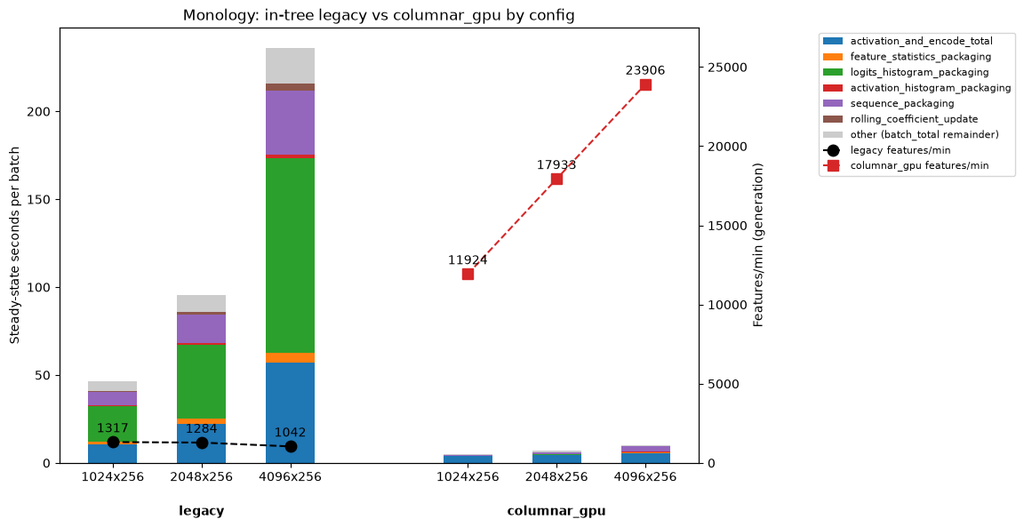

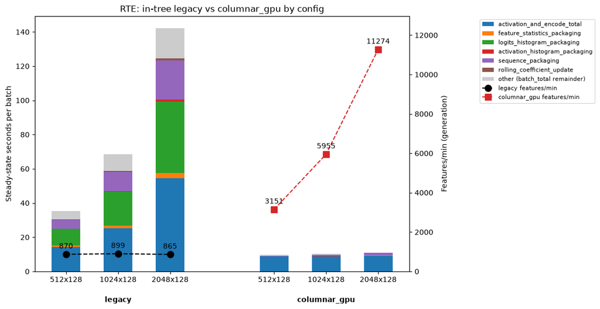

## Chart (d): 2-way GPU/CPU resource-dimension comparison

GiB metrics on the primary axis; GPU utilization on a secondary axis with a fixed 0-100% ceiling.

DB import timing is intentionally excluded here (see chart (b)); this chart focuses on host/GPU resource utilization peaks.

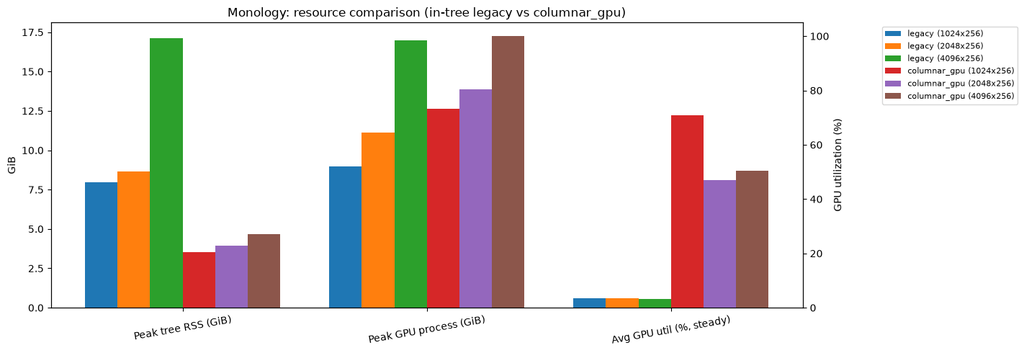

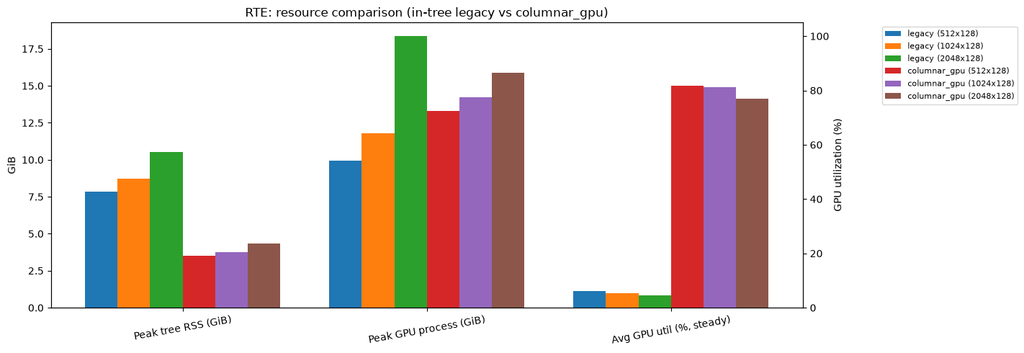

## Primary benchmark data

|  | scenario | path | config | avg_batch_s | features_per_min | import_wall_s | activation_rows | e2e_features_per_min |
| --- | --- | --- | --- | --- | --- | --- | --- | --- |
| 0 | Monology | Preserved baseline | 1024x256 | 47.216616 | 1301.236849 | 59.024802 | 137329 | 991.402423 |
| 1 | Monology | legacy | 1024x256 | 46.656779 | 1316.850443 | 59.441590 | 137329 | 998.745448 |
| 2 | Monology | legacy | 2048x256 | 95.697872 | 1284.041090 | 118.623089 | 271721 | 980.266675 |
| 3 | Monology | legacy | 4096x256 | 235.871763 | 1041.922089 | 245.170100 | 546237 | 827.017276 |
| 4 | Monology | columnar_gpu | 4096x256x24576 | 235.357856 | 1044.197141 | 101.449367 | 513747 | 942.619722 |
| 5 | Monology | columnar_gpu | 4096x256x2490 | 28.221365 | 8708.296102 | 96.825410 | 492756 | 4687.596805 |
| 6 | Monology | columnar_gpu | 4096x256x4096 | 43.336747 | 5670.937850 | 94.804314 | 496703 | 3665.990023 |
| 7 | Monology | columnar_gpu | 1024x256 | 5.152442 | 11924.442587 | 25.794551 | 137085 | 5296.058731 |
| 8 | Monology | columnar_gpu | 2048x256 | 6.852209 | 17932.902887 | 49.663875 | 271228 | 6377.354472 |
| 9 | Monology | columnar_gpu | 4096x256 | 10.280372 | 23905.748560 | 98.148191 | 544871 | 7058.535576 |
| 10 | RTE | Preserved baseline | 512x128 | 35.907964 | 855.520526 | 48.168508 | 65131 | 640.666149 |
| 11 | RTE | legacy | 512x128 | 35.316398 | 869.850885 | 46.185630 | 65131 | 655.530536 |
| 12 | RTE | legacy | 1024x128 | 68.350905 | 898.890800 | 91.496327 | 130392 | 673.499684 |
| 13 | RTE | legacy | 2048x128 | 142.108217 | 864.693138 | 194.910456 | 258602 | 643.904237 |
| 14 | RTE | columnar_gpu | 512x128 | 9.750281 | 3150.678316 | 13.806455 | 65186 | 2326.938639 |
| 15 | RTE | columnar_gpu | 1024x128 | 10.317777 | 5954.771052 | 24.354584 | 130479 | 3744.874770 |
| 16 | RTE | columnar_gpu | 2048x128 | 10.899763 | 11273.639797 | 47.336424 | 258745 | 5405.151298 |